# Question 2

Amir Zehavi, Adam Uziel and Itay Asraf

6/5/2021

```r
#install.packages("hexbin")
library(tidyverse)
library(tidymodels)
library(tidytext)
library(lubridate)
library(here)
library(scales)
library(glue)
library(textrecipes)
library(gridExtra)
library(ggpubr)
library(hexbin)
```

importing the data

```r
trump_tweets <- read_rds(here::here("data", "trump.rds"))
civiqs_polls <- read_csv(here::here("data", "civiqs_poll.csv"))
```

## Exploring corona concern poll data

```r
glimpse(civiqs_polls)
```

```
## Rows: 41
## Columns: 4
## $ date <chr> "2/25/2020", "2/26/2020", "2/27/2020", "2/28/2020", "2/29/2020", ~
## $ dem  <dbl> 35, 35, 35, 35, 36, 37, 37, 37, 38, 39, 39, 41, 43, 46, 49, 52, 5~
## $ rep  <dbl> -57, -58, -58, -58, -58, -58, -57, -56, -56, -56, -56, -56, -54, ~
## $ diff <dbl> 92, 93, 93, 93, 94, 95, 94, 93, 94, 95, 95, 97, 97, 97, 97, 96, 9~
```

### Civiq Poll Data Types

date -

Represents the date each poll was conducted

dem, rep -

Data Type: integer

Represent the net number of people concerned about the coronavirus by party. (net number concerned = people concerned - people not concerned)

diff -

Data Type: integer

Represents the magnitude of the difference between the concern of republicans and democrats (diff = |dem - rep|)

#### Civiq distribution

```r
# Getting an idea of the variable distributions
summary(civiqs_polls)
```

```
##      date                dem             rep              diff
##  Length:41          Min.   :35.00   Min.   :-58.00   Min.   :59.00
##  Class :character   1st Qu.:39.00   1st Qu.:-56.00   1st Qu.:65.00
##  Mode  :character   Median :66.00   Median :-21.00   Median :87.00
##                     Mean   :60.29   Mean   :-20.85   Mean   :81.15
##                     3rd Qu.:78.00   3rd Qu.: 13.00   3rd Qu.:94.00
##                     Max.   :82.00   Max.   : 23.00   Max.   :97.00
```

## First impressions of the data

We can see that democrats are much more concerned than republicans about covid. In fact, in the poll where republicans are most worried about covid, they are still less worried about it than democrats were when they were least worried!

High diff values tell us that republicans and democrats were significantly at odds with respect to covid worry throughout the data set.

Note that date is unordered

# Exploring trump’s tweets

```r
glimpse(trump_tweets)
```

```
## Rows: 1,549
## Columns: 6
## $ date      <dttm> 2020-04-04 16:48:47, 2020-04-04 16:48:32, 2020-04-04 16:47:~
## $ favorites <chr> "0", "74661", "0", "0", "0", "0", "0", "0", "32032", "0", "0~
## $ id        <chr> "1246434545357987842", "1246434478744047616", "1246434186942~
## $ isRetweet <lgl> TRUE, FALSE, TRUE, TRUE, TRUE, TRUE, TRUE, TRUE, FALSE, TRUE~
## $ retweets  <chr> "4410", "10449", "3063", "3321", "2500", "108116", "4579", "~
## $ text      <chr> "RT @IvankaTrump: Great reconnecting with President Kaljulai~
```

### Data Types

date - Data Type: datetime Represents the date of each tweet

favorites - Data Type: character The number of favorites of each tweet. It is 0 if the tweet is retweeted

id - Data Type: character The tweet’s id

isRetweet - Data Type: logical True if the tweet is a retweet

retweets - Data Type: character The number of retweets the tweet got

text - Data type: character Represents the text of the tweet

### A look at the distribution

```r
# we chose to use head here - summary isnt useful for character variables
head(trump_tweets)
```

```
##                  date favorites                  id isRetweet retweets
## 1 2020-04-04 16:48:47         0 1246434545357987842      TRUE     4410
## 2 2020-04-04 16:48:32     74661 1246434478744047616     FALSE    10449
## 3 2020-04-04 16:47:22         0 1246434186942128129      TRUE     3063
## 4 2020-04-04 16:46:39         0 1246434007258144768      TRUE     3321
## 5 2020-04-04 16:46:31         0 1246433974869798913      TRUE     2500
## 6 2020-04-04 16:45:39         0 1246433754161217536      TRUE   108116
##                                                                                                                                           text
## 1 RT @IvankaTrump: Great reconnecting with President Kaljulaid of Estonia.  Her leadership and innovativeness is truly admirable! https://t.c…
## 2                                                                                                       I fully agree! https://t.co/yAQ71uhk9Q
## 3                                                                    RT @AdrianaCohen16: https://t.co/o3rKp1rwRX @IvankaTrump #PaidFamilyLeave
## 4 RT @senrobportman: I couldn’t agree more! Our National Parks are national treasures. This legislation will ensure they are preserved and pr…
## 5            RT @SenCapito: Proud co-sponsor of this important conservation legislation that helps keep West Virginia #WildAndWonderful. #LWCF
## 6                                                                  RT @realDonaldTrump: THE UNITED STATES LOVES ITALY! https://t.co/DESUJ4QM41
```

### First impressions

We can see that for all of the retweets, the number of favorites is zero, and the tweet begins with RT @(originaltweeter)

```r
civiqs_polls<-civiqs_polls%>%
  rename(Date=date)

#change the format of the date.
civiqs_polls$Date<-as.Date(civiqs_polls$Date, format =  "%m/%d/%Y")
```

```r
trump_tweets$date <- ymd_hms(trump_tweets$date)
trump_tweets <- trump_tweets %>%
  rename(date_hour = date) %>%
  mutate(date = as.Date(date_hour),
         favorites = as.integer(favorites),
         retweets = as.integer(retweets))

glimpse(trump_tweets)
```

```
## Rows: 1,549
## Columns: 7
## $ date_hour <dttm> 2020-04-04 16:48:47, 2020-04-04 16:48:32, 2020-04-04 16:47:~
## $ favorites <int> 0, 74661, 0, 0, 0, 0, 0, 0, 32032, 0, 0, 0, 0, 0, 0, 0, 0, 0~
## $ id        <chr> "1246434545357987842", "1246434478744047616", "1246434186942~
## $ isRetweet <lgl> TRUE, FALSE, TRUE, TRUE, TRUE, TRUE, TRUE, TRUE, FALSE, TRUE~
## $ retweets  <int> 4410, 10449, 3063, 3321, 2500, 108116, 4579, 1938, 6306, 363~
## $ text      <chr> "RT @IvankaTrump: Great reconnecting with President Kaljulai~
## $ date      <date> 2020-04-04, 2020-04-04, 2020-04-04, 2020-04-04, 2020-04-04,~
```

At the first part, we saw that it was more difficult to convince the republicans that the pandemic was dangerous. Because of that we want to check how the republicans’ mood changes after tweets.

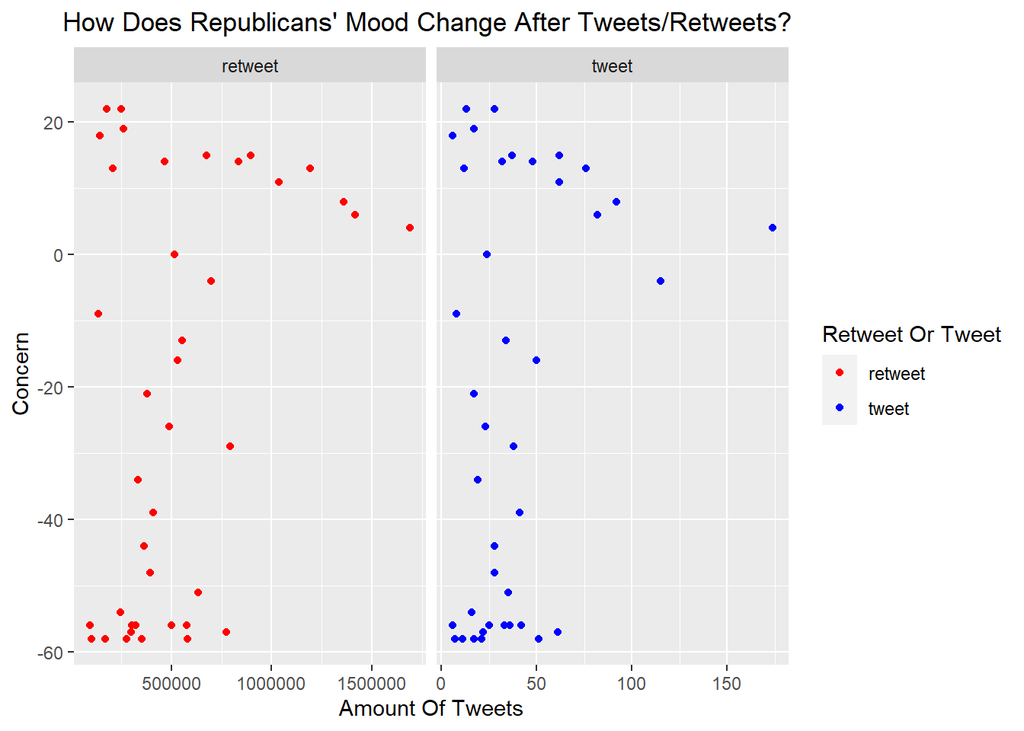

```r
# number of tweets each day.
sum_tweets<-trump_tweets %>%
  group_by(date)%>%
  count(date) %>%
  rename(tweet=n)


tweets_connection<-trump_tweets %>%
  group_by(date) %>%

  #sum the retweets for each day
  summarise(retweet = sum(retweets)) %>%

  #join- To see how the the mood of republicans changed
  inner_join(civiqs_polls,by=c('date' = 'Date')) %>%
  inner_join(sum_tweets,by='date')%>%
  pivot_longer(cols=c(tweet,retweet),
                names_to="Retweet_Tweet",
                values_to ="num_tweets")%>%
  select(rep,Retweet_Tweet,num_tweets)

ggplot(tweets_connection,aes(num_tweets,rep,color=factor(Retweet_Tweet)))+

  geom_point(stat='identity')+

  theme(plot.title = element_text(hjust = 0.5)) +

  labs(title="How Does Republicans' Mood Change After Tweets/Retweets? ",
       x='Amount Of Tweets',
       y='Concern',

       color='Retweet Or Tweet')+
  # correspond the colors to the diff
  scale_color_manual(values = c("red","blue"))+
  facet_wrap(~Retweet_Tweet,scales="free_x")
```

```r
#ggsave("Republican mood after Retweets.png")
```

**Explanation:** It’s hard to say, if the amount of tweets or retweets affect on the concern of Republicans, but as general,the more tweets/retweets, the Republicans more concerned.

This is nice information, **but it doesn’t tell us how the covid data affects Republicans. Maybe subject like elections,politics cause their concern.**

As a result, we will check at first the average amount of covid retweets, and the average of no covid retweets.

```r
#number of covid tweets and no covid tweets.
count_tweets_covid<- trump_tweets %>%
  filter(str_detect(text, 'COVID-19|Covid-19|Covid-19|covid|coronavirus|COVID 19|covid 19')) %>%
  distinct(id)%>%
  count(id)%>%
  summarise(sum=sum(n))

count_tweets_not_covid<- trump_tweets %>%
  filter(!str_detect(text, 'COVID-19|Covid-19|Covid-19|covid|coronavirus|COVID 19|covid 19')) %>%
  distinct(id)%>%
  count(id)%>%
  summarise(sum=sum(n))

print(paste("The Number Of Covid tweets is:",count_tweets_covid))
```

```
## [1] "The Number Of Covid tweets is: 65"
```

```r
print(paste("The Number Of Not Covid tweets is:",count_tweets_not_covid))
```

```
## [1] "The Number Of Not Covid tweets is: 1084"
```

```r
#The average of Covid and No covid retweets
tweet_text<-trump_tweets %>%
  filter(str_detect(text, 'COVID-19|Covid-19|Covid-19|covid|coronavirus|COVID 19|covid 19|COVID19|COVID|COVID_19'))%>%
  distinct(id,retweets)%>%
  summarise(mean(retweets))

tweet_text2<-trump_tweets %>%
  filter(!str_detect(text, 'COVID-19|Covid-19|Covid-19|covid|coronavirus|COVID 19|covid 19|COVID19|COVID|COVID_19')) %>%
   distinct(id,retweets)%>%
  summarise(mean(retweets))


print(paste("The Avg Of Covid Retweets is:",tweet_text))
```

```
## [1] "The Avg Of Covid Retweets is: 7323.24545454545"
```

```r
print(paste("The Avg Of Not Covid Retweets is:",tweet_text2))
```

```
## [1] "The Avg Of Not Covid Retweets is: 14755.4600577478"
```

**Explanation:** The average of retweets of no covid tweets is 2 times larger than retweets of covid tweets, but it is because there are many more tweets of no covid!

**The interest in the subject of the corona in people is very large and with a very small number of tweets !**

How the Republicans’ concern after a day with covid tweets?

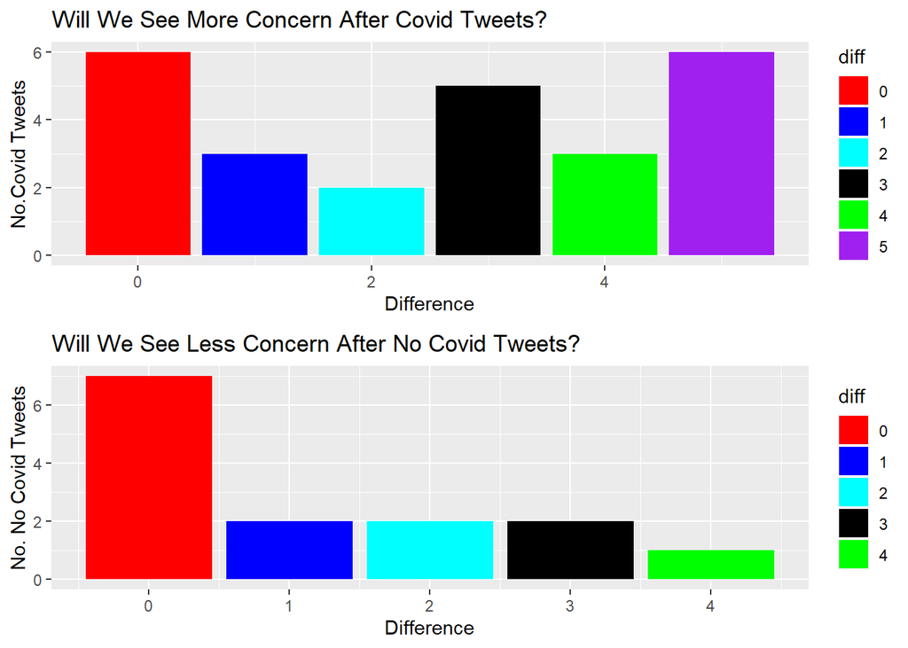

```r
pivot_data<- read_rds(here::here("data", "pivot_data.rds"))
diff_previous<-pivot_data%>%
  filter(rep_or_dem=='rep')%>%
   mutate(diff = Current_Mood-lag(Current_Mood))%>%
  na.omit()%>%
  select(Date,diff)

diff_previous$Date<-as.Date(diff_previous$Date)

#how the covid tweets affect on the rep concern day by day
covid_diff<-trump_tweets %>%
    inner_join(diff_previous,by=c('date' = 'Date')) %>%
  filter(str_detect(text, 'COVID-19|Covid-19|Covid-19|covid|coronavirus|COVID   19|covid 19|#COVID19'))%>%
  distinct(date,diff) %>%
  select(diff,date)

#how the no covid tweets affect on the rep concern day by day
notcovid_diff<-trump_tweets %>%
    inner_join(diff_previous,by=c('date' = 'Date')) %>%
  filter(!str_detect(text, 'COVID-19|Covid-19|Covid-19|covid|coronavirus|COVID 19|covid 19|virus'))%>%
  distinct(date,diff) %>%
  select(diff,date)


#Checking the common dates in days with covid tweets and dayws without covid tweets. If the day with covid, so he will belong to covid_diff,else: to notcovid_diff

common <- intersect(covid_diff$date, notcovid_diff$date)

notcovid_diff<-notcovid_diff %>%
  filter(!(date %in% common))


#covid tweets graph
covid_retweet_graph<-ggplot(covid_diff,aes(diff,fill=factor(diff)))+

  geom_histogram(position='dodge',alpha=0.7) +

                 stat_count()+

  labs(title="Will We See More Concern After Covid Tweets?",
       x='Difference',
       y='No.Covid Tweets',
       fill='diff')+
  scale_fill_manual(values = c("red","blue","cyan","black","green","purple"))


#not covid tweets graph
notcovid_retweet_graph<-ggplot(notcovid_diff,aes(diff,fill=factor(diff)))+

 geom_histogram(position='dodge',alpha=0.7) +

                 stat_count()+

  labs(title="Will We See Less Concern After No Covid Tweets?",
       x='Difference',
       y='No. No Covid Tweets',
       fill='diff')+

    scale_fill_manual(values = c("red","blue","cyan","black","green","purple"))

grid.arrange(covid_retweet_graph,notcovid_retweet_graph,ncol=1)
```

```r
#ggsave("Covid tweets and concern.png")
```

**Explanation:** We can see that after days with covid tweets there are more concern than days without covid tweets. Talking about the virus causes more concern, more afraid .

Because the results, we think that from the tweets that doesn’t talk about covid, the main reason is the election to president. We will check this:

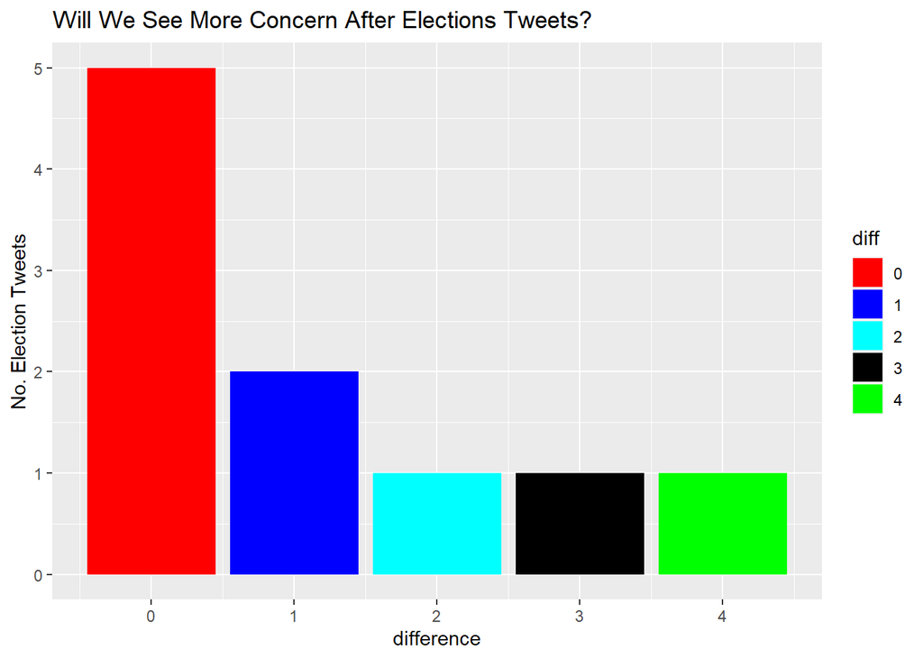

```r
diff_previous<-pivot_data%>%
  filter(rep_or_dem=='rep')%>%
   mutate(diff = Current_Mood-lag(Current_Mood))%>%
  na.omit()%>%
  select(Date,diff)

diff_previous$Date<-as.Date(diff_previous$Date)

notcovid_diff2<-trump_tweets %>%
  filter(!str_detect(text, 'COVID-19|Covid-19|Covid-19|covid|coronavirus|COVID 19|covid 19|virus'))%>%
  distinct(date,text) %>%
  filter(!(date %in% common))


#Checking the common dates in days with covid tweets and dayws without covid tweets. If the day with covid, so he will belong to covid_diff,else: to notcovid_diff


#split the text to word at each day
tr<-notcovid_diff2 %>%
  separate_rows(text, sep = ' ') %>%
  filter(str_detect(text, "^elect*|^vote*"))%>%
  select(text,date)%>%
  inner_join(diff_previous,by=c('date'='Date')) %>%
  distinct(date,diff)

ggplot(tr,aes(diff,fill=factor(diff)))+

 geom_histogram(position='dodge',alpha=0.7) +
                 stat_count()+

  labs(title="Will We See More Concern After Elections Tweets?",
       x='difference',
       y='No. Election Tweets',
       fill='diff')+

    scale_fill_manual(values = c("red","blue","cyan","black","green","purple"))
```

```r
#ggsave("Concern after elections tweets.png")
```

```r
trump_tweets <- trump_tweets %>%
  mutate(
    wday = wday(date),
    weekend = if_else(wday %in% c(6, 7), "Weekend", "Weekday"),
    day_part = if_else(hour(date_hour) %in% seq(0,11), "AM", "PM")
  ) %>%
  # count words
  rowwise() %>%
  mutate(n_words = text %>% str_count("\\w+") %>% sum()) %>%
  ungroup()
trump_tweets %>% head(10)
```

```
## # A tibble: 10 x 11
##    date_hour           favorites id    isRetweet retweets text  date        wday
##    <dttm>                  <int> <chr> <lgl>        <int> <chr> <date>     <dbl>
##  1 2020-04-04 16:48:47         0 1246~ TRUE          4410 "RT ~ 2020-04-04     7
##  2 2020-04-04 16:48:32     74661 1246~ FALSE        10449 "I f~ 2020-04-04     7
##  3 2020-04-04 16:47:22         0 1246~ TRUE          3063 "RT ~ 2020-04-04     7
##  4 2020-04-04 16:46:39         0 1246~ TRUE          3321 "RT ~ 2020-04-04     7
##  5 2020-04-04 16:46:31         0 1246~ TRUE          2500 "RT ~ 2020-04-04     7
##  6 2020-04-04 16:45:39         0 1246~ TRUE        108116 "RT ~ 2020-04-04     7
##  7 2020-04-04 16:44:20         0 1246~ TRUE          4579 "RT ~ 2020-04-04     7
##  8 2020-04-04 16:43:49         0 1246~ TRUE          1938 "RT ~ 2020-04-04     7
##  9 2020-04-04 16:41:32     32032 1246~ FALSE         6306 "Tha~ 2020-04-04     7
## 10 2020-04-04 16:29:54         0 1246~ TRUE          3630 "RT ~ 2020-04-04     7
## # ... with 3 more variables: weekend <chr>, day_part <chr>, n_words <int>
```

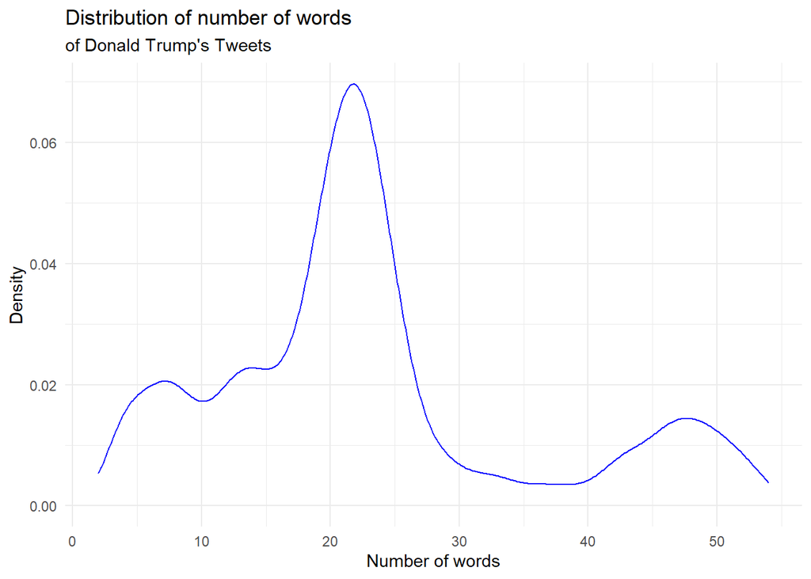

```r
ggplot(trump_tweets, aes(x = n_words)) +
  geom_density(color = "blue") +
  labs(
    title = "Distribution of number of words",
    subtitle = "of Donald Trump's Tweets",
    x = "Number of words",
    y = "Density"
  ) +
  theme_minimal() +
  scale_x_continuous(breaks = scales::pretty_breaks(n = 8))
```

```r
# ggsave("Words_per_tweet_dist.png")
```

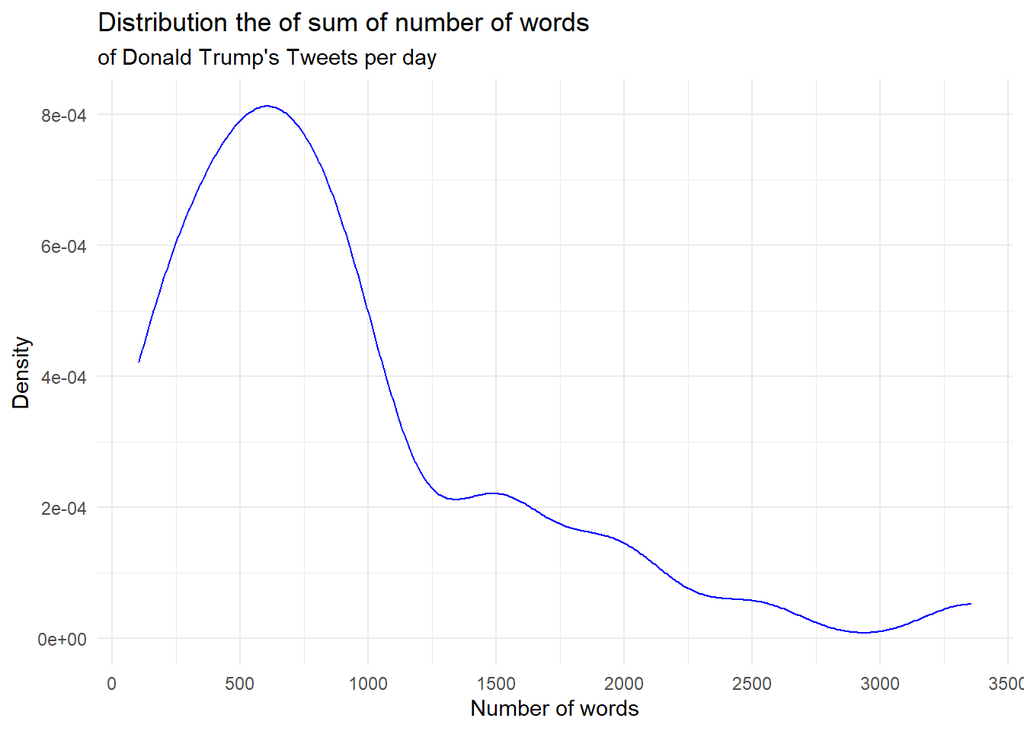

```r
trump_tweets_sum_words <- trump_tweets %>%
         group_by(date, weekend) %>%
         summarise(words_per_date = sum(n_words, na.rm = T), .groups = "drop")
ggplot(trump_tweets_sum_words, aes(x = words_per_date)) +
  geom_density(color = "blue") +
  labs(
    title = "Distribution the of sum of number of words",
    subtitle = "of Donald Trump's Tweets per day",
    x = "Number of words",
    y = "Density"
  ) +
  theme_minimal() +
  scale_x_continuous(breaks = scales::pretty_breaks(n = 8))
```

```r
# ggsave("Words_per_day_dist.png")
```

We can see that most days trump tweets between about 100 and 1200 words, with a minority of tweets dragging on past that.

Lets check the relationship between number of words, favorites and retweets:

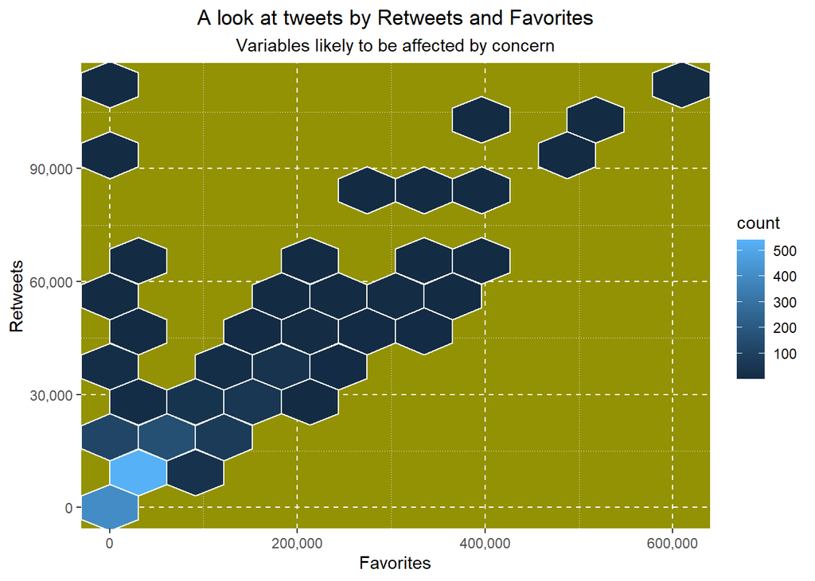

```r
#silver #fffff0
# nice brown #FFDB6D
options(scipen = 1000L)
trump_tweets %>% ggplot(aes(x = favorites, y = retweets)) +
  geom_hex(bins = 10, color = "#FFFFF0") +
  scale_x_continuous(labels = comma) +
  scale_y_continuous(labels = comma) +
  theme(panel.background = element_rect(fill = "#939204"),
        panel.grid.major = element_line(linetype = "dashed"),
        panel.grid.minor = element_line(linetype = "dotted"),
        plot.title = element_text(hjust = 0.5),
        plot.subtitle = element_text(hjust = 0.5),
        ) +
  labs(x = "Favorites",
       y = "Retweets",
       title = "A look at tweets by Retweets and Favorites",
       subtitle = "Variables likely to be affected by concern")
```

```r
options(scipen = 0L)
```

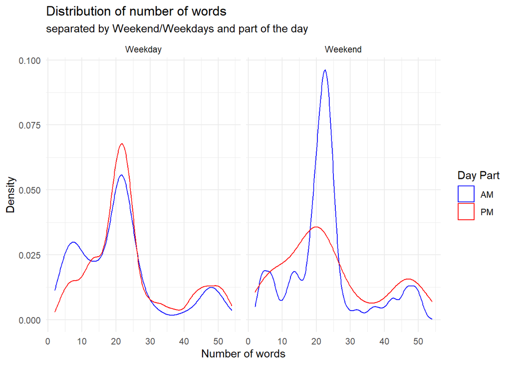

```r
ggplot(trump_tweets, mapping = aes(x = n_words, color = day_part)) +
  geom_density() +
  facet_wrap(~ weekend) +
  scale_colour_manual(values = c("blue", "red"), name = "Day Part") +
  theme_minimal() +
  labs(
    title = "Distribution of number of words",
    subtitle = "separated by Weekend/Weekdays and part of the day",
    x = "Number of words",
    y= "Density"
  )
```

```r
# ggsave("Words_by_weekend_Timeofday_dist.png")
```

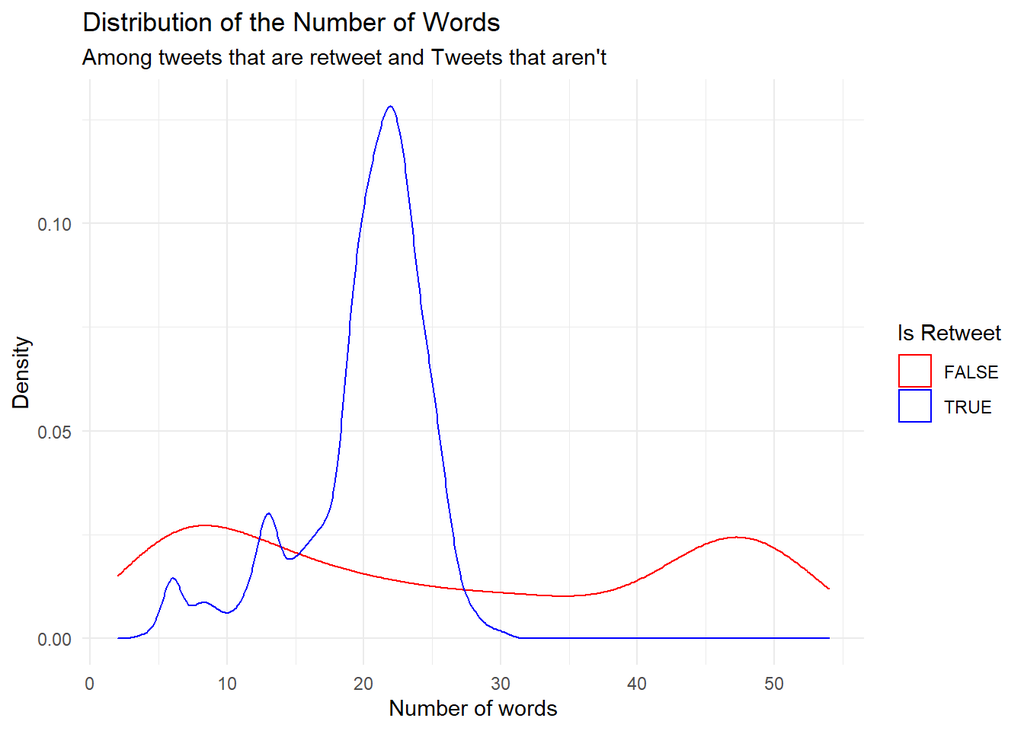

```r
ggplot(data = trump_tweets, mapping = aes(x = n_words, color = factor(isRetweet)))+
  geom_density()+
  theme_minimal() +
  labs(
    x = "Number of words",
    y = "Density",
    title = "Distribution of the Number of Words",
    subtitle = "Among tweets that are retweet and Tweets that aren't",
    color = "Is Retweet"
  ) +
  scale_colour_manual(values = c("red", "blue"))
```

```r
# ggsave("Num_words_by_retweet_dist.png")
```

In this graph we can see that Retweets seem to have a limit of about 30 words, such that most of them have between 15 and 27 words. Original tweets, on the other hand, have an almost flat distribution of words.

```r
# unifies covid spellings, unnests words. Does not remove stopwords, so we will
# be able to show the cleaning process
trump_tweets_words <- trump_tweets %>%
  mutate(
    text = str_replace_all(text, "COVID-19", "COVID_19"),
    text = str_replace_all(text, "COVID 19", "COVID_19"),
    text = str_replace_all(text, "Covid-19", "COVID_19"),
    text = str_replace_all(text, "Covid 19", "COVID_19"),
    text = str_replace_all(text, "#COVID19", "COVID_19"),
    text = str_replace_all(text, "covid 19", "COVID_19"),
    text = str_replace_all(text, "Coronavirus", "COVID_19"),
    text = str_replace_all(text, "coronavirus", "COVID_19")
  ) %>%
  unnest_tokens(word, text)
trump_tweets_words
```

```
## # A tibble: 34,399 x 11
##    date_hour           favorites id          isRetweet retweets date        wday
##    <dttm>                  <int> <chr>       <lgl>        <int> <date>     <dbl>
##  1 2020-04-04 16:48:47         0 1246434545~ TRUE          4410 2020-04-04     7
##  2 2020-04-04 16:48:47         0 1246434545~ TRUE          4410 2020-04-04     7
##  3 2020-04-04 16:48:47         0 1246434545~ TRUE          4410 2020-04-04     7
##  4 2020-04-04 16:48:47         0 1246434545~ TRUE          4410 2020-04-04     7
##  5 2020-04-04 16:48:47         0 1246434545~ TRUE          4410 2020-04-04     7
##  6 2020-04-04 16:48:47         0 1246434545~ TRUE          4410 2020-04-04     7
##  7 2020-04-04 16:48:47         0 1246434545~ TRUE          4410 2020-04-04     7
##  8 2020-04-04 16:48:47         0 1246434545~ TRUE          4410 2020-04-04     7
##  9 2020-04-04 16:48:47         0 1246434545~ TRUE          4410 2020-04-04     7
## 10 2020-04-04 16:48:47         0 1246434545~ TRUE          4410 2020-04-04     7
## # ... with 34,389 more rows, and 4 more variables: weekend <chr>,
## #   day_part <chr>, n_words <int>, word <chr>
```

```r
# Unifies covid spellings, unnesting bigrams. Shows results
trump_tweets_bigrams<-  trump_tweets %>%
  mutate(
    text = str_replace_all(text, "COVID-19", "COVID_19"),
    text = str_replace_all(text, "COVID 19", "COVID_19"),
    text = str_replace_all(text, "Covid-19", "COVID_19"),
    text = str_replace_all(text, "Covid 19", "COVID_19"),
    text = str_replace_all(text, "#COVID19", "COVID_19"),
    text = str_replace_all(text, "covid 19", "COVID_19"),
    text = str_replace_all(text, "Coronavirus", "COVID_19"),
    text = str_replace_all(text, "coronavirus", "COVID_19")
  ) %>%
  unnest_tokens(bigram, text, token = "ngrams", n = 2) %>%

  # add index for later grouping
  mutate(i = row_number()) %>%

  # makes 4 rows for every row above. 2 with each word.
  unnest_tokens(word, bigram,token = "tweets", drop = FALSE) %>%

  # takes the new word column mentioned above and gets rid of all rows with
  # stopwords as 'words'
  anti_join(stop_words) %>%
  # gets rid of of rows where the 'word' col includes the following words.
   filter(!(word %in% c("rt", "tco", "https", "RT", "tc"))) %>%
   group_by(i) %>%
   filter(n() == 2) %>%
   summarise(bigram = unique(bigram), .groups = "drop")
trump_tweets_bigrams
```

```
## # A tibble: 6,416 x 2
##        i bigram
##    <int> <chr>
##  1     6 president kaljulaid
##  2    27 o3rkp1rwrx ivankatrump
##  3    28 ivankatrump paidfamilyleave
##  4    32 couldn’t agree
##  5    36 national parks
##  6    39 national treasures
##  7    50 sencapito proud
##  8    57 conservation legislation
##  9    62 west virginia
## 10    63 virginia wildandwonderful
## # ... with 6,406 more rows
```

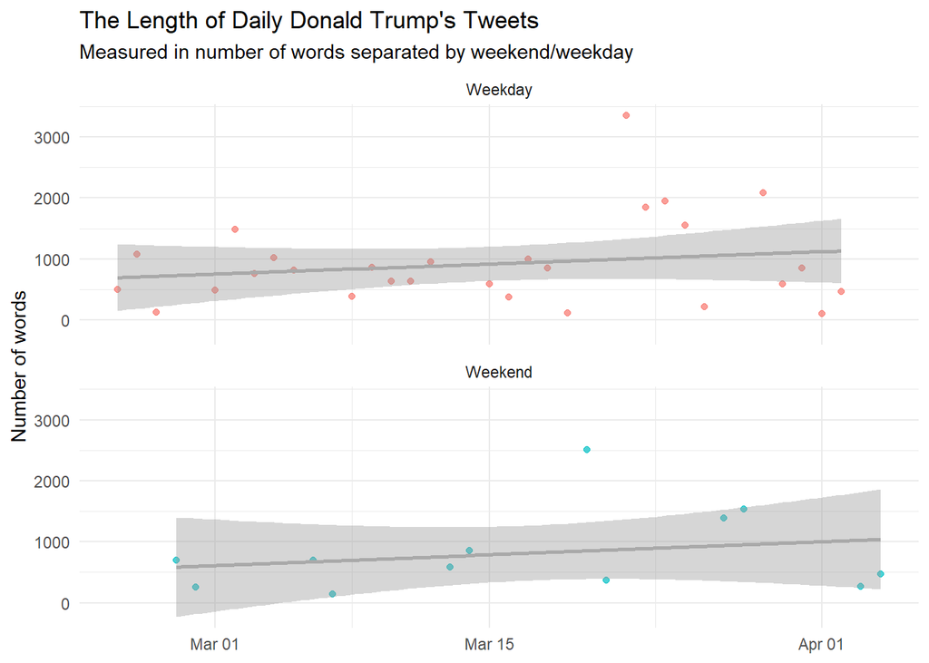

```r
ggplot(trump_tweets_sum_words, aes(x = date, y = words_per_date, color = weekend))+
  geom_point( alpha = 0.7) +
  geom_smooth(aes(x = date, y = words_per_date), method = lm, formula = y ~ x, color = "darkgray") +
  labs(
    title = "The Length of Daily Donald Trump's Tweets",
    subtitle = "Measured in number of words separated by weekend/weekday",
    x = NULL, y = "Number of words", color = NULL, shape = NULL
  ) +
  theme_minimal() +
  facet_wrap(~ weekend, nrow = 2)  +
  theme(legend.position = "none"
        )
```

```r
# ggsave("Tweet_length_by_weekday_over_time.png")
```

It doesn’t look like this would be a good feature, as the number of tweets seems to rise similarly whether its a weekday or not. Lets check this quantitatively:

```r
# get r squared and see explicitly whether or not this is a good feature
lm_words1 <- lm(words_per_date ~ date, data = trump_tweets_sum_words %>%
                 filter(weekend=="Weekend"))
glance(lm_words1)$r.squared
```

```
## [1] 0.05322384
```

```r
lm_words2 <- lm(words_per_date ~ date, data = trump_tweets_sum_words %>%
                 filter(weekend=="Weekday"))
glance(lm_words2)$r.squared
```

```
## [1] 0.03584939
```

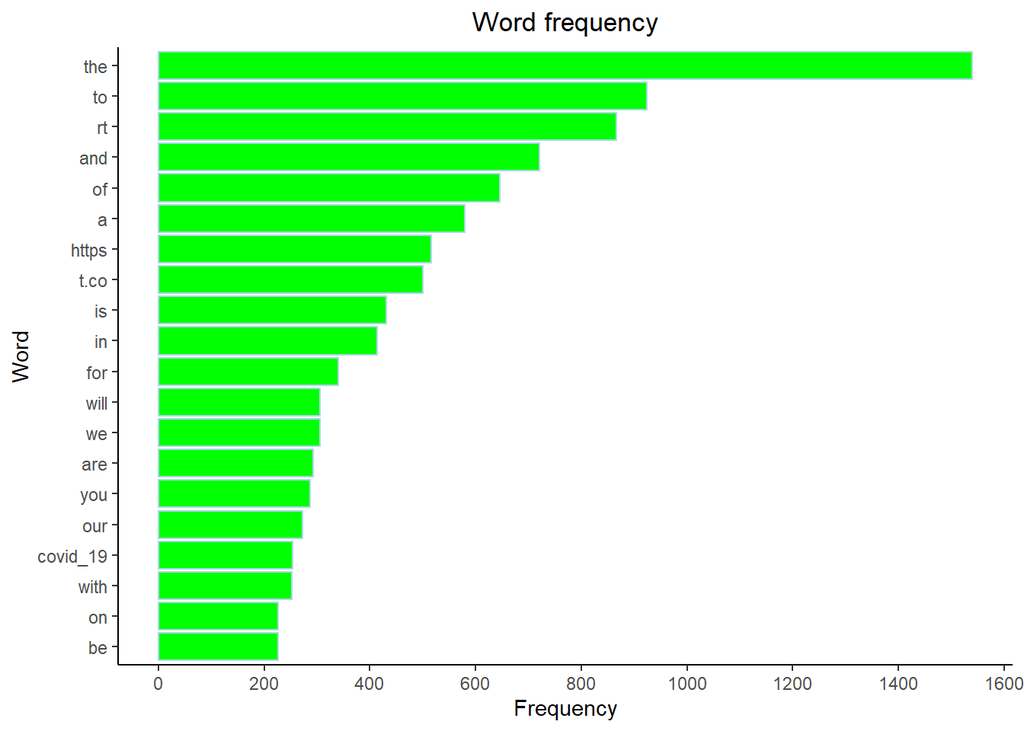

```r
trump_tweets_words %>%
  count(word, sort = TRUE) %>%
  unique() %>%
  head(20) %>%
  ggplot(aes(y = fct_reorder(word, n), x = n)) +
  geom_bar(stat = "identity", fill = "green", color="lightblue") +
  scale_x_continuous(breaks = scales::pretty_breaks(n = 8))+
  theme_classic() +
  ggtitle("Word frequency") +
  theme(plot.title = element_text(hjust = 0.5)) +
  labs(x = "Frequency",
       y = "Word")
```

```r
# ggsave("Word frequency uncleaned.png")
```

We got a bunch of stopwords and artifacts from tweets. (t.co, rt) Lets clean it and see how the word frequency changes

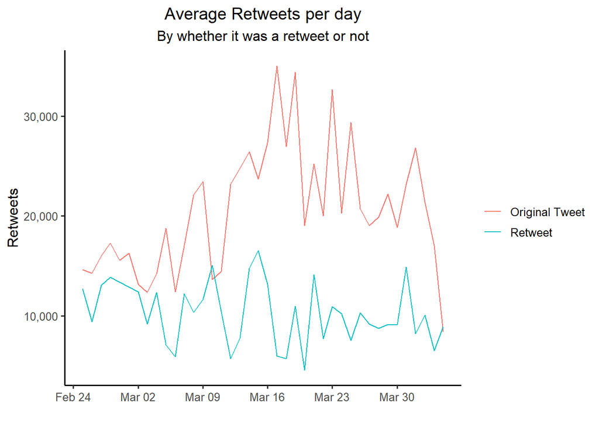

```r
avg_retweets <- trump_tweets %>%
  group_by(date, isRetweet, .groups = 'drop') %>%
  summarize(retweets = mean(retweets))

# key labels
avg_retweets$faclabs <- factor(avg_retweets$isRetweet,
                               labels = c('Original Tweet', 'Retweet'))
avg_retweets%>% ggplot(aes(x = date, y = retweets, group= isRetweet, color=faclabs)) +
  geom_line() +
  ggtitle("Average Retweets per day") +
  theme_classic2() +
  scale_x_date(breaks = scales::pretty_breaks(n = 8))+
  scale_y_continuous(labels = comma) +
  theme(
        plot.title = element_text(hjust = 0.5),
        plot.subtitle = element_text(hjust = 0.5),
        legend.title = element_blank()) +
  labs(subtitle = "By whether it was a retweet or not",
       y = "Retweets", x = "",
       color = "")
```

```r
#ggsave("Average Retweets Per Day by isRetweet.png")
```

```r
# gets of basic stopwords and tweet stopwords in the df with unnested words
trump_tweets_words <- trump_tweets_words %>%
  anti_join(stop_words) %>%
  filter(!(word %in% c("rt", "tco", "https", "RT", "tc", "t.co", "amp")))
```

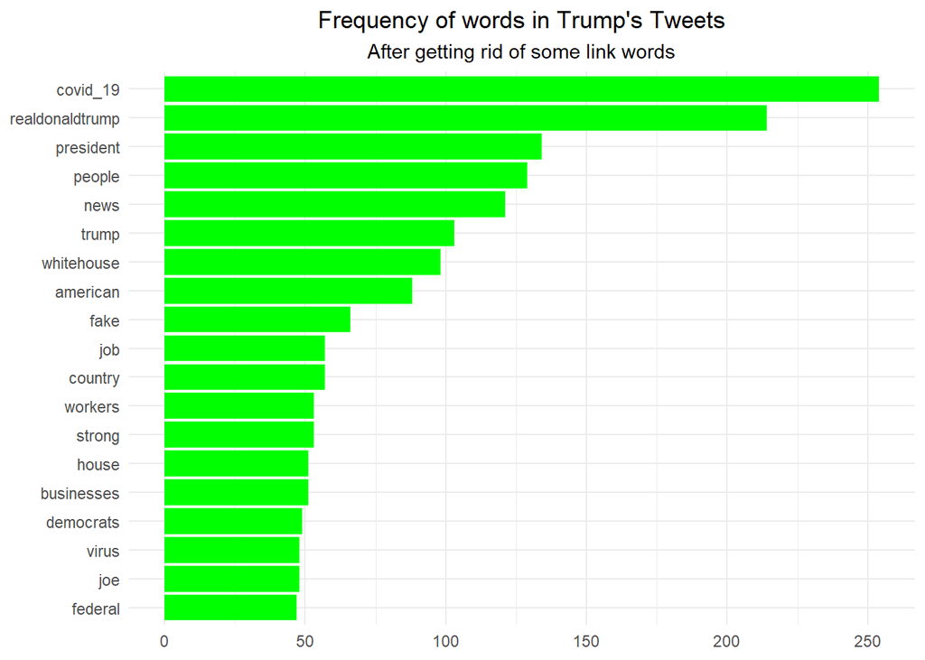

```r
trump_tweets_words %>%
  count(word, sort = TRUE) %>%
  unique() %>%
  filter(n > 45) %>%
ggplot(aes(y = fct_reorder(word, n), x = n)) +
  geom_bar(stat = "identity", fill = "green") +
  scale_x_continuous(breaks = scales::pretty_breaks(n = 8))+
  labs(
    title = "Frequency of words in Trump's Tweets",
    subtitle = "After getting rid of some link words",
    y = NULL, x = NULL) +
  theme_minimal() +
  theme(plot.title = element_text(hjust = 0.5),
        plot.subtitle = element_text(hjust = 0.5))
```

```r
#ggsave("Word frequency.png")
```

After cleaning we can see that the most frequent words completely changed. Now we can see the contents of trunp’s tweets. You can see that he tweets often about covid, himself, jobs and workers (things important to his base) and his political enemies.

### Add sentiments function

```r
add_sentiments <- function(df, with_capitals = FALSE) {
  basic_sentiments <- get_sentiments("bing")
  discrete_sentiments <- get_sentiments("nrc")

  # If capitals should be added
  if(with_capitals){
    cap_basic_sentiments <- basic_sentiments %>%
      mutate(word = firstup(word))

    cap_disc_sentiments <- discrete_sentiments %>%
      mutate(word = firstup(word))

    basic_sentiments <- union(basic_sentiments, cap_basic_sentiments)
    discrete_sentiments <- union(discrete_sentiments, cap_disc_sentiments)
  }

#tweet_an - tweets we will be analyzing
tweet_an <- df

# change name of n_gram column so we can join it with get_sentiments, remove id
#tweet_an <- tweet_an %>%
#  rename(word = n_grams) %>%
#  select(!id)

# dataframe with positive and negative sentiments for each word
pos_neg_tweets <- tweet_an %>%
  left_join(basic_sentiments, by="word")

# dataframe with discrete emotions for each word
discrete_tweets <- tweet_an %>%
  left_join(discrete_sentiments, by="word")

sentiment_tweets <- full_join(discrete_tweets, pos_neg_tweets, by="word")

# in the full join a duplicate n was created. Remove it and rename sentiment cols
sentiment_tweets <- sentiment_tweets %>%
  select(!n.y) %>%
  rename(n = n.x,
         emotion = sentiment.x,
         positivity = sentiment.y)
sentiment_tweets
}
```

```r
df <- trump_tweets_words %>%
  group_by(word) %>%

  # remember that there are copies here. We don't want copies the sentiment
  # dataframe.
  unique() %>%
  count(word, sort=TRUE)

sentiment_tweets <- add_sentiments(df, with_capitals = FALSE)
sentiment_tweets %>% head(20)
```

```
## # A tibble: 20 x 4
## # Groups:   word [19]
##    word                n emotion  positivity
##    <chr>           <int> <chr>    <chr>
##  1 covid_19          173 <NA>     <NA>
##  2 realdonaldtrump   161 <NA>     <NA>
##  3 president          93 positive <NA>
##  4 president          93 trust    <NA>
##  5 people             88 <NA>     <NA>
##  6 news               78 <NA>     <NA>
##  7 whitehouse         68 <NA>     <NA>
##  8 trump              67 surprise positive
##  9 american           53 <NA>     <NA>
## 10 fake               44 negative negative
## 11 job                44 positive <NA>
## 12 country            38 <NA>     <NA>
## 13 democrats          37 <NA>     <NA>
## 14 joe                37 <NA>     <NA>
## 15 biden              36 <NA>     <NA>
## 16 strong             35 <NA>     positive
## 17 house              34 <NA>     <NA>
## 18 federal            33 <NA>     <NA>
## 19 virus              31 negative negative
## 20 workers            31 <NA>     <NA>
```

Oh no! The dataframe has a lot of NAs! Lets clean it:

```r
sentiment_tweets <- sentiment_tweets %>%
  mutate(emotion = case_when(word == "COVID19" | word=="#COVID19"|
                               word=="covid_19"|word=="covid19"~ "fear",
                             word == "Trump"|word=="trump" ~ "none",
                             is.na(emotion) ~ "none",
                             TRUE ~ as.character(emotion)),
         positivity = case_when(word == "President"|word=="president" ~ "positive",
                                word == "American"|word=="american" ~ "positive",
                                word == "COVID19" | word=="#COVID19" ~ "negative",
                                word == "workers" ~ "positive",
                                # We will assume that on average, the word Trump
                                # will be considered neutral.
                                word == "Trump"|word=="trump" ~ "neither",
                                emotion %in% c("positive, trust, joy, anticipation") ~ "positive",
                                emotion %in% c("fear", 'negative', 'disgust', 'sadness',
                                               'anger', "surprise") ~ "negative",
                                is.na(positivity) ~ "neither",
                                TRUE ~ as.character(positivity))) %>%
  mutate(emotion = factor(emotion, levels = c("joy", "anticipation", "trust",
                                   "positive", "surprise", "none", "anger",
                                   "fear", "disgust", "sadness", "negative")),
         positivity = factor(positivity, levels = c("positive", "neither", "negative")))

sentiment_tweets %>% head(10)
```

```
## # A tibble: 10 x 4
## # Groups:   word [9]
##    word                n emotion  positivity
##    <chr>           <int> <fct>    <fct>
##  1 covid_19          173 fear     negative
##  2 realdonaldtrump   161 none     neither
##  3 president          93 positive positive
##  4 president          93 trust    positive
##  5 people             88 none     neither
##  6 news               78 none     neither
##  7 whitehouse         68 none     neither
##  8 trump              67 none     neither
##  9 american           53 none     positive
## 10 fake               44 negative negative
```

Thats better!

### Graphing positivity/negativity

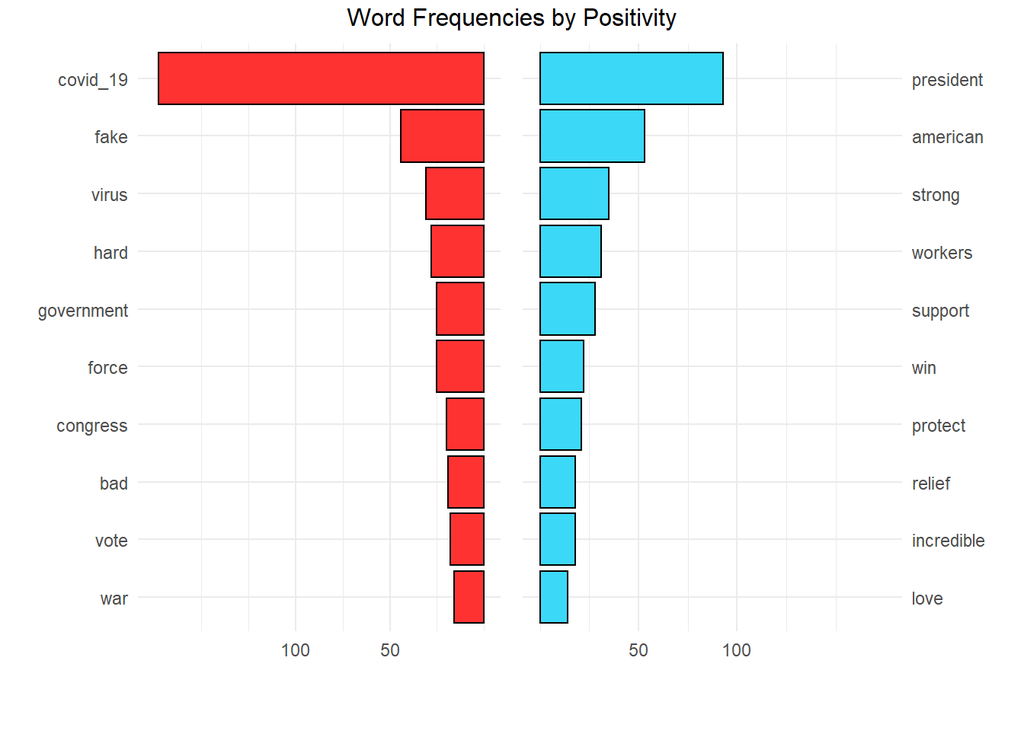

```r
num_to_show <- 10

pos_plt <- sentiment_tweets %>%
  filter(positivity == "positive") %>%
  mutate(word = fct_reorder(word, n)) %>%
  select(!emotion) %>%
  distinct() %>%
  head(num_to_show) %>%
  ggplot(aes(x = n, y = fct_reorder(word, n))) +
  geom_col(fill = "#3CD8F7", color = "black") +
  scale_y_discrete(position = "right") +
  scale_x_continuous(breaks = c(50, 100),
                     labels = c(50, 100),
                     limits = c(0, 175)) +
  theme_minimal() +
  labs(y = "", x="")

neg_plt <- sentiment_tweets %>%
  filter(positivity == "negative") %>%
  select(!emotion) %>%
  distinct() %>%
  mutate(word = fct_reorder(word, n)) %>%
  head(num_to_show) %>%
  ggplot(aes(x = -n, y = fct_reorder(word, n), )) +
  geom_col(fill = "#FF3232", color="black") +
  scale_x_continuous(breaks = c(-50, -100),
                     labels = c(50, 100),
                     limits = c(-175, 0)) +
  theme(legend.position = "None",
        axis.text.x = element_blank()) +
  theme_minimal() +
  labs(y = "", x="")

ggarrange(neg_plt, pos_plt, common.legend = TRUE) %>%
  annotate_figure(top = "Word Frequencies by Positivity",
                  bottom = "")
```

```r
#ggsave("Word Freq by positivity.png")
```

[figure not shown]

```r
trump_tweets_bigrams %>%
  count(bigram, sort = TRUE) %>%
  filter(n > 15) %>%
  ggplot(aes(x = fct_reorder(bigram ,n ), y = n, fill=TRUE)) +
  geom_col(color = "black") +
  theme_classic() +
  ggtitle("Frequency of the twelve highest words") +
  theme(axis.title.x.bottom = element_blank(),
        axis.text.x = element_text(angle = 90, hjust = 1, vjust = 0.5),
        plot.title = element_text(hjust = 0.5),
        legend.position = "None") +
  scale_fill_brewer() +
  labs(y = "Frequency")
```

```r
#ggsave("Bigram Frequency.png")
```

When looking at bigrams, we see that fake news, himself, the nicknames he gave to his political enemies, and various coronavirus related terms (covid19 task, covid19 response) are prevalent.

```r
# import the civiq data
civiqs_polls <- read_csv(here::here("data", "civiqs_poll.csv"))

# reformat date and combine with trump_tweets_words.Then add a variable to check
# whether or not the republicans are concerned.
polls_words_tweets <- civiqs_polls %>%
  separate(date, into = c("month", "day", "year"), sep = "/") %>%
  unite(date, year, month, day, sep = "-") %>%
  mutate(date = as.Date(date)) %>%
  left_join(trump_tweets_words)  %>%
  filter(!is.na(id)) %>%
  mutate(Is_CONCERNED = if_else(rep<0, "not concerned", "concerned")) %>%
  unique()
polls_words_tweets %>% head(10)
```

```
## # A tibble: 10 x 15
##    date         dem   rep  diff date_hour           favorites id       isRetweet
##    <date>     <dbl> <dbl> <dbl> <dttm>                  <int> <chr>    <lgl>
##  1 2020-02-25    35   -57    92 2020-02-25 23:56:35         0 1232424~ TRUE
##  2 2020-02-25    35   -57    92 2020-02-25 23:56:35         0 1232424~ TRUE
##  3 2020-02-25    35   -57    92 2020-02-25 23:56:35         0 1232424~ TRUE
##  4 2020-02-25    35   -57    92 2020-02-25 23:56:35         0 1232424~ TRUE
##  5 2020-02-25    35   -57    92 2020-02-25 23:40:00         0 1232420~ TRUE
##  6 2020-02-25    35   -57    92 2020-02-25 23:40:00         0 1232420~ TRUE
##  7 2020-02-25    35   -57    92 2020-02-25 23:40:00         0 1232420~ TRUE
##  8 2020-02-25    35   -57    92 2020-02-25 23:40:00         0 1232420~ TRUE
##  9 2020-02-25    35   -57    92 2020-02-25 23:40:00         0 1232420~ TRUE
## 10 2020-02-25    35   -57    92 2020-02-25 23:40:00         0 1232420~ TRUE
## # ... with 7 more variables: retweets <int>, wday <dbl>, weekend <chr>,
## #   day_part <chr>, n_words <int>, word <chr>, Is_CONCERNED <chr>
```

For our analysis, we believe that the ratio between positive and negative words in a tweet could help our model predict concern

```r
#Introducing the random 15 values
polls_words_tweets%>%
  left_join(sentiment_tweets,by="word") %>%
  group_by(id) %>%
  count(positivity)%>%
  head(15)
```

```
## # A tibble: 15 x 3
## # Groups:   id [6]
##    id                  positivity     n
##    <chr>               <fct>      <int>
##  1 1232064874156523523 positive       4
##  2 1232064874156523523 neither       18
##  3 1232064874156523523 negative       2
##  4 1232067592086487043 neither        2
##  5 1232130587324014593 positive       3
##  6 1232130587324014593 neither       14
##  7 1232130587324014593 negative      13
##  8 1232130591862247424 positive       6
##  9 1232130591862247424 neither       12
## 10 1232130591862247424 negative       8
## 11 1232155591537254400 positive       1
## 12 1232155591537254400 neither       14
## 13 1232155591537254400 negative      12
## 14 1232155595438018567 positive       2
## 15 1232155595438018567 neither        9
```

```r
# do the same for trump_tweets. (The original dataframe)
polls_tweets<- civiqs_polls %>%
  separate(date, into = c("month", "day", "year"), sep = "/") %>%
  unite(date, year, month, day, sep = "-") %>%
  mutate(date = as.Date(date)) %>%
  left_join(trump_tweets)  %>%
  filter(!is.na(id))%>%
  mutate(Is_CONCERNED = if_else(rep<0, "not concerned", "concerned"),
         Is_CONCERNED = as.factor(Is_CONCERNED))
polls_tweets %>% head(10)
```

```
## # A tibble: 10 x 15
##    date         dem   rep  diff date_hour           favorites id       isRetweet
##    <date>     <dbl> <dbl> <dbl> <dttm>                  <int> <chr>    <lgl>
##  1 2020-02-25    35   -57    92 2020-02-25 23:56:35         0 1232424~ TRUE
##  2 2020-02-25    35   -57    92 2020-02-25 23:40:00         0 1232420~ TRUE
##  3 2020-02-25    35   -57    92 2020-02-25 23:16:14         0 1232414~ TRUE
##  4 2020-02-25    35   -57    92 2020-02-25 22:52:55     53055 1232408~ FALSE
##  5 2020-02-25    35   -57    92 2020-02-25 22:51:21         0 1232407~ TRUE
##  6 2020-02-25    35   -57    92 2020-02-25 22:48:21         0 1232407~ TRUE
##  7 2020-02-25    35   -57    92 2020-02-25 22:43:33     41251 1232405~ FALSE
##  8 2020-02-25    35   -57    92 2020-02-25 22:01:29     88400 1232395~ FALSE
##  9 2020-02-25    35   -57    92 2020-02-25 16:04:51         0 1232305~ TRUE
## 10 2020-02-25    35   -57    92 2020-02-25 16:03:32         0 1232305~ TRUE
## # ... with 7 more variables: retweets <int>, text <chr>, wday <dbl>,
## #   weekend <chr>, day_part <chr>, n_words <int>, Is_CONCERNED <fct>
```

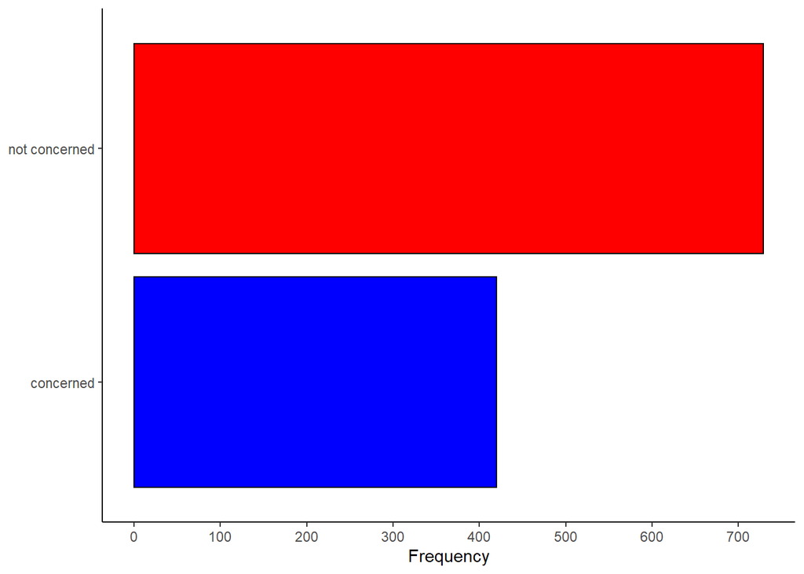

```r
# plot Is_Concerned ratio of true and false
polls_tweets %>%
  unique() %>%
  ggplot(aes(x = Is_CONCERNED, fill = Is_CONCERNED)) +
  geom_bar(color = "black") +
  scale_fill_manual(values = c("blue", "red")) +
  labs(
    y = "Frequency"
  ) +
  theme_classic() +
  theme(axis.title.y = element_blank() ,
        legend.position = "none") +
  scale_y_continuous(breaks = scales::pretty_breaks(n = 8)) +
  coord_flip()
```

```r
# Calculate it.
concerned <- polls_tweets %>%
  unique() %>%
  count(Is_CONCERNED)

# percent of tweets where republicans are concerned
concern_ratio <- concerned$n[1]/(concerned$n[2] + concerned$n[1])
concern_ratio
```

```
## [1] 0.3655352
```

```r
#ggsave("Concern Ratio.png")
```

Since republicans were more likely to be not concerned in the data, we calculated the probabililty that a random tweet will have republicans concerned. Our model will have to be more sure than 50% that a tweet is concerning in order to classify it as such.

Now lets calculate a similar ratio for every tweet to use as a feature

```r
# Calculate Tweet Positivity and Negativity
tweet_sent_count <- polls_words_tweets %>%
  left_join(sentiment_tweets, by="word") %>%
  group_by(id) %>%
  count(positivity, .drop = FALSE) %>%
  pivot_wider(id_cols = id, names_from = positivity, values_from = n) %>%

  # create the ratio: pos or neg words/total words
  mutate(pos_ratio = positive/(positive + neither + negative),
         neg_ratio = negative/(positive + neither + negative))
tweet_sent_count %>% head(5)
```

```
## # A tibble: 5 x 6
## # Groups:   id [5]
##   id                  positive neither negative pos_ratio neg_ratio
##   <chr>                  <int>   <int>    <int>     <dbl>     <dbl>
## 1 1232064874156523523        4      18        2    0.167     0.0833
## 2 1232067592086487043        0       2        0    0         0
## 3 1232130587324014593        3      14       13    0.1       0.433
## 4 1232130591862247424        6      12        8    0.231     0.308
## 5 1232155591537254400        1      14       12    0.0370    0.444
```

We can see that the majority of our words are classified as neither. In the beginning we wanted to use a ratio of positivity to negativity, but because of this we normalized positivity and relativity by the number of words per tweet.

Glancing at TFIDF. We will use this with step_tfidf in a recipe

```r
# Calculate tfidf
tweet_tf_idf <- polls_words_tweets %>%
  count(Is_CONCERNED, word, sort = TRUE) %>% # count
  group_by(Is_CONCERNED) %>%
  mutate(total = sum(n)) %>%
  bind_tf_idf(word, Is_CONCERNED, n)

# Before using it in a recipe, lets look at tfidf to get a sense of what it is
tweet_tf_idf %>%
  select(-total) %>%
  arrange(desc(tf_idf)) %>%
  head(10)
```

```
## # A tibble: 10 x 6
## # Groups:   Is_CONCERNED [2]
##    Is_CONCERNED  word            n      tf   idf  tf_idf
##    <chr>         <chr>       <int>   <dbl> <dbl>   <dbl>
##  1 not concerned kag2020        29 0.00398 0.693 0.00276
##  2 not concerned mini           28 0.00385 0.693 0.00267
##  3 concerned     ventilators    12 0.00304 0.693 0.00211
##  4 not concerned texas          21 0.00288 0.693 0.00200
##  5 concerned     hospitals       9 0.00228 0.693 0.00158
##  6 not concerned carolina       15 0.00206 0.693 0.00143
##  7 concerned     caresact        8 0.00203 0.693 0.00140
##  8 concerned     supplies        8 0.00203 0.693 0.00140
##  9 concerned     lamestream      7 0.00177 0.693 0.00123
## 10 not concerned agenda         12 0.00165 0.693 0.00114
```

We can see that the important tfidf words are not necessarily the ones mentioned often. They are the ones that identify specific tweets, as expected

```r
polls_tweets_more_tidy<- polls_tweets %>%
  mutate(
    text = str_replace_all(text, "COVID-19", "COVID_19"),
    text = str_replace_all(text, "COVID 19", "COVID_19"),
    text = str_replace_all(text, "Covid-19", "COVID_19"),
    text = str_replace_all(text, "Covid 19", "COVID_19"),
    text = str_replace_all(text, "#COVID19", "COVID_19"),
    text = str_replace_all(text, "covid 19", "COVID_19"),
    text = str_replace_all(text, "Coronavirus", "COVID_19"),
    text = str_replace_all(text, "coronavirus", "COVID_19"),
    text = str_remove_all(text, "https"),
    text = str_remove_all(text, "t.co"),
    text = str_remove_all(text, "rt"),
    text = str_remove_all(text, "RT"),
    text = str_remove_all(text, "tco"),
    text = str_remove_all(text, "tc")
  ) %>%
  unique() %>%

  # add sentiment analysis to final data
  left_join(tweet_sent_count, by="id") %>%

  # select only columns needed for analysis
  select(Is_CONCERNED, id, text, isRetweet, n_words, pos_ratio, neg_ratio, wday, n_words)

polls_tweets_more_tidy %>% head(5)
```

```
## # A tibble: 5 x 8
##   Is_CONCERNED  id     text          isRetweet n_words pos_ratio neg_ratio  wday
##   <fct>         <chr>  <chr>         <lgl>       <int>     <dbl>     <dbl> <dbl>
## 1 not concerned 12324~ " @GOPLeader~ TRUE            9     0        0          3
## 2 not concerned 12324~ " @jaketappe~ TRUE           18     0.188    0.25       3
## 3 not concerned 12324~ " @gr8tjude_~ TRUE           18     0        0.25       3
## 4 not concerned 12324~ "True, but w~ FALSE          12     0        0          3
## 5 not concerned 12324~ " @gr8tjude_~ TRUE           16     0.214    0.0714     3
```

# Logistic Regression

```r
# Set a seed and split data
set.seed(111)
tweet_split <- initial_split(polls_tweets_more_tidy, strata = Is_CONCERNED)
tweet_train <- training(tweet_split)
tweet_test  <- testing(tweet_split)
```

Inititalize logistic regression

```r
lasso_mod <- logistic_reg(penalty = 0.005, mixture = 1) %>%
  set_engine("glmnet")
```

Create the recipe. We will pick whether or not the tweet is a retweet, the number of words, the day of the week and the tfidf of the words as features. Note that picking the tweet as a feature can let the model memorize which tweets happened while republicans were concerned or not - which it can’t know if we were to use this model for prediction.

We tried a number of different parameters and this one turned out best. The resulting ROC curves and data are in the files.

```r
# Create a recipe for analysis

# Our features will be: the day of the week, the number of words,
# (if trumps base is concerned, the length of his tweets will probably change)
# the proportion of positive and negative words, and whether or not the tweet is
# a Retweet.
tweet_rec <- recipe(Is_CONCERNED ~ text + isRetweet + wday + n_words +
                      pos_ratio + neg_ratio, data = tweet_train) %>%

  # tokenize into words
  step_tokenize(text, token = "words") %>%

  # get rid of stopwords
  step_stopwords(text) %>%

  # stem tokens (will tweet meanings be clearer if we only take words' 'roots'?)
  #step_stem(text) %>%

  # make bigrams
  step_ngram(text, num_tokens = 2, min_num_tokens = 1) %>%

  # keep the 600 most frequent words
  step_tokenfilter(text, max_tokens = 600) %>%

  # calculate tf-idf to use for text identification
  step_tfidf(text)
```

Creating Workflow

```r
# create workflow
tweet_wflow <- workflow() %>%
  add_model(lasso_mod) %>%
  add_recipe(tweet_rec)
```

Setting seed, vfolds

```r
set.seed(111)
tweet_folds <- vfold_cv(tweet_train, v = 10, strata = Is_CONCERNED)
#write_rds(tweet_folds, here::here("data", "tweet_folds.rds"), compress = "bz2")
```

#### fit logistic regression

```r
# The file name indicates the variables added: RT- isRetweet, WD -wwekday, N -
# num of words, PR/NR - pos/neg ratios
file_name <- "fit_T_RT_WD_N_PR_NR_tfidf.rds"
# tweet_fit_rs <- tweet_wflow %>%
#   fit_resamples(
#     resamples = tweet_folds,
#     control = control_resamples(save_pred = TRUE)
#   )

#write_rds(tweet_fit_rs, here::here("DifferentModelsData", file_name), compress = "xz")

tweet_fit_rs <- read_rds(here::here("DifferentModelsData", file_name))

# collect metrics and predictions
tweet_train_metrics <- collect_metrics(tweet_fit_rs)
tweet_train_pred <- collect_predictions(tweet_fit_rs)
tweet_train_metrics_not_sum <- collect_metrics(tweet_fit_rs, summarize = F)
tweet_train_metrics
```

```
## # A tibble: 2 x 6
##   .metric  .estimator  mean     n std_err .config
##   <chr>    <chr>      <dbl> <int>   <dbl> <fct>
## 1 accuracy binary     0.667    10  0.0123 Preprocessor1_Model1
## 2 roc_auc  binary     0.690    10  0.0148 Preprocessor1_Model1
```

```r
tweet_train_metrics_not_sum %>% head(10)
```

```
## # A tibble: 10 x 5
##    id     .metric  .estimator .estimate .config
##    <chr>  <chr>    <chr>          <dbl> <fct>
##  1 Fold01 accuracy binary         0.678 Preprocessor1_Model1
##  2 Fold01 roc_auc  binary         0.760 Preprocessor1_Model1
##  3 Fold02 accuracy binary         0.690 Preprocessor1_Model1
##  4 Fold02 roc_auc  binary         0.671 Preprocessor1_Model1
##  5 Fold03 accuracy binary         0.621 Preprocessor1_Model1
##  6 Fold03 roc_auc  binary         0.692 Preprocessor1_Model1
##  7 Fold04 accuracy binary         0.644 Preprocessor1_Model1
##  8 Fold04 roc_auc  binary         0.682 Preprocessor1_Model1
##  9 Fold05 accuracy binary         0.724 Preprocessor1_Model1
## 10 Fold05 roc_auc  binary         0.726 Preprocessor1_Model1
```

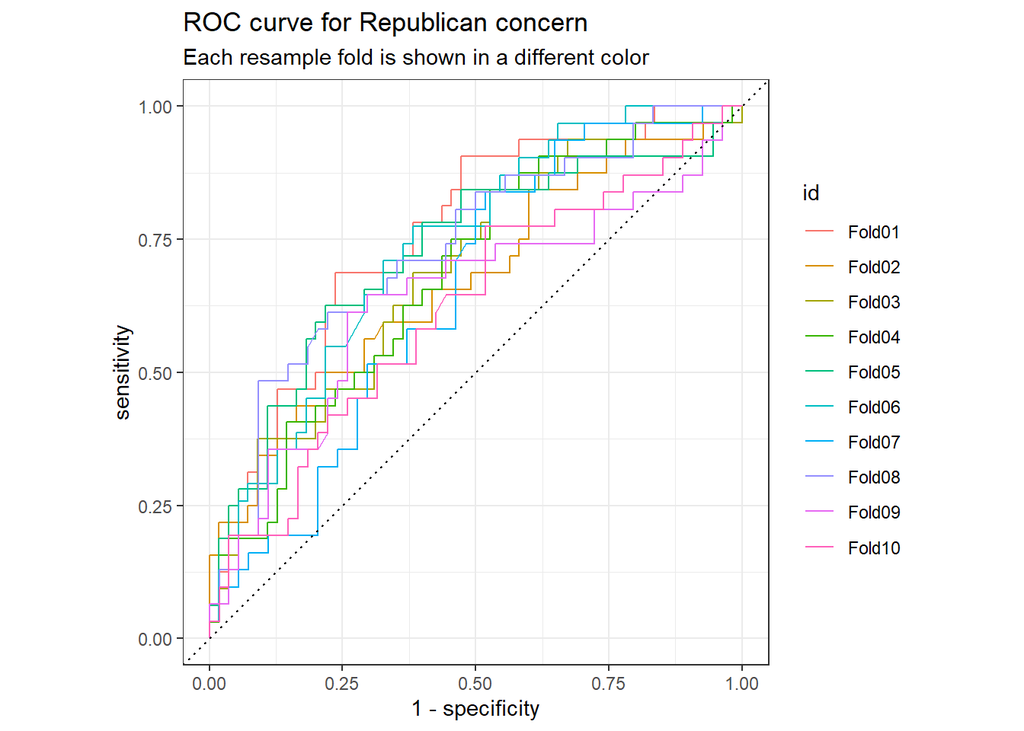

```r
tweet_train_pred %>%
  group_by(id) %>%
  roc_curve(truth = Is_CONCERNED, .pred_concerned) %>%
  autoplot() +
  labs(
    title = "ROC curve for Republican concern",
    subtitle = "Each resample fold is shown in a different color"
  )
```

Every fold except fold 9 and 7 are above the line at all times, so our model is probably going to preform well.

```r
tweet_fit <- tweet_wflow %>%
  fit(data = tweet_train)

tweet_test_pred <- predict(tweet_fit, new_data = tweet_test, type = "prob") %>%
  bind_cols(tweet_test %>% select(Is_CONCERNED, text, isRetweet, wday,n_words,
                                  pos_ratio, neg_ratio))

# Rsquared and Root mean squared error
numerical_pred <- tweet_test_pred %>% mutate(Is_CONCERNED = ifelse(Is_CONCERNED == "concerned", 0, 1))
rmse(numerical_pred, truth=Is_CONCERNED, estimate =.pred_concerned)
```

```
## # A tibble: 1 x 3
##   .metric .estimator .estimate
##   <chr>   <chr>          <dbl>
## 1 rmse    standard       0.691
```

```r
rsq(numerical_pred, truth=Is_CONCERNED, estimate=.pred_concerned)
```

```
## # A tibble: 1 x 3
##   .metric .estimator .estimate
##   <chr>   <chr>          <dbl>
## 1 rsq     standard      0.0960
```

If we check the Root mean squared error and R squared, we can see that the error is large (remembering that our data is between the values of zero and one) and theR squared is small. These are not good signs for the predictive power of the model, as they indicate that the prediction is not a linear fit for the data. (and the model explains only about 10% of the variance in concern)

We will check Pearson’s R

```r
# Pearson's R
cor.test(numerical_pred$.pred_concerned,numerical_pred$Is_CONCERNED, method="pearson")
```

```
##
##  Pearson's product-moment correlation
##
## data:  numerical_pred$.pred_concerned and numerical_pred$Is_CONCERNED
## t = -5.5015, df = 285, p-value = 8.385e-08
## alternative hypothesis: true correlation is not equal to 0
## 95 percent confidence interval:
##  -0.4108851 -0.2012843
## sample estimates:
##        cor
## -0.3098443
```

Note about linear models measurements and accuracy: It is worth mentioning that the fact that there were significantly more non- concerned tweets than concerned tweets could affect the above measurements. The model’s accuracy won’t necessarily be measured by its closeness to the above metrics. For examplel, if it correctly classifies the tweet, just barely, and gives it a probability of 0.37 of being concerned, that will make RMSE large and R squared small, even though the model correctly classifies the phenomena.

Finally, lets see how the model holds up

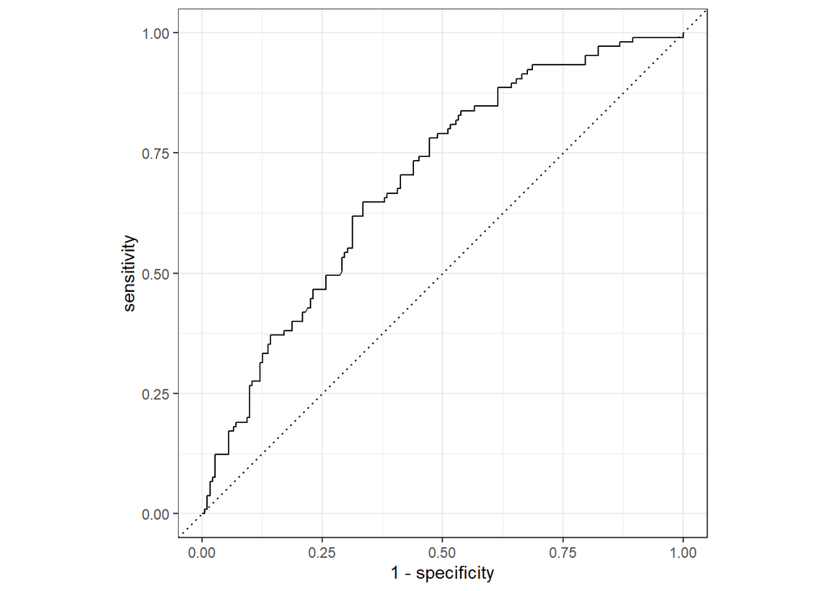

```r
tweet_test_pred %>%
  roc_curve(truth = Is_CONCERNED, .pred_concerned) %>%
  autoplot()
```

```r
#ggsave(str_c(file_name, ".png"))
```

The model seems to have succeeded in classifying republican concern by retweet. This is partially due to our decision to use a logistic regression model - a binary classification of concern is much easier to do than a numerical prediction. We included many variables in our analysis, although it is worth mentioning that the inclusion of text as a variable may have overfit the data, as the model may be able to “memorize” for which text the concern was high and for which text it was low.

```r
tweet_test_pred %>%
  roc_auc(truth = Is_CONCERNED, .pred_concerned)
```

```
## # A tibble: 1 x 3
##   .metric .estimator .estimate
##   <chr>   <chr>          <dbl>
## 1 roc_auc binary         0.693
```

```r
# lets take a look at the model's results
tweet_test_pred %>%
  filter(Is_CONCERNED == "concerned", `.pred_not concerned` > concern_ratio) %>%
  head(15)
```

```
## # A tibble: 15 x 9
##    .pred_concerned `.pred_not conce~ Is_CONCERNED text   isRetweet  wday n_words
##              <dbl>             <dbl> <fct>        <chr>  <lgl>     <dbl>   <int>
##  1          0.504              0.496 concerned    " @Wh~ TRUE          1      13
##  2          0.188              0.812 concerned    " @GO~ TRUE          1      21
##  3          0.260              0.740 concerned    " @se~ TRUE          1      21
##  4          0.420              0.580 concerned    " @Wh~ TRUE          1      17
##  5          0.233              0.767 concerned    " @Wh~ TRUE          1      18
##  6          0.442              0.558 concerned    " @be~ TRUE          1      10
##  7          0.123              0.877 concerned    " @Te~ TRUE          1      25
##  8          0.0485             0.951 concerned    " @Va~ TRUE          1      27
##  9          0.479              0.521 concerned    "Mari~ FALSE         1       7
## 10          0.587              0.413 concerned    " @re~ TRUE          1       6
## 11          0.219              0.781 concerned    " @Se~ TRUE          1      22
## 12          0.135              0.865 concerned    " @Se~ TRUE          1      22
## 13          0.405              0.595 concerned    " @Se~ TRUE          1      19
## 14          0.420              0.580 concerned    " @Wh~ TRUE          1      21
## 15          0.182              0.818 concerned    " @De~ TRUE          1      19
## # ... with 2 more variables: pos_ratio <dbl>, neg_ratio <dbl>
```

## Tune:

```r
lasso_mod_tune <- logistic_reg(penalty = tune(), mixture = 1) %>%
  set_engine("glmnet") %>%
  set_mode("classification")
```

We will use the same recipe we used in the original model.

```r
tweet_rec_tune <- recipe(Is_CONCERNED ~ text + isRetweet + wday + n_words +
                      pos_ratio + neg_ratio, data = tweet_train) %>%
  # tokenize
  step_tokenize(text, token = "words") %>%

  # stopwords
  step_stopwords(text) %>%

  # make bigrams
  step_ngram(text, num_tokens = 2, min_num_tokens = 1) %>%

  # keep the 600 most frequent words
  step_tokenfilter(text, max_tokens = tune(), min_times = 5) %>%

  # calculate tf-idf to use for text identification
  step_tfidf(text)
```

```r
tweet_wflow_tune <- workflow() %>%
  add_model(lasso_mod_tune) %>%
  add_recipe(tweet_rec_tune)
```

```r
param_grid <- grid_regular(
  penalty(range = c(-4, 0)),
  max_tokens(range = c(100, 750)),
  levels = 5
)
```

train models with all possible values of tuning parameters:

```r
# Train with tuning
# set.seed(24)
# tweet_fit_rs_tune <- tune_grid(
#  tweet_wflow_tune,
#  resamples = tweet_folds,
#  grid = param_grid,
#  control = control_grid(save_pred = TRUE)
# )

# write_rds(tweet_fit_rs_tune, here::here("data", "tweet_fit_rs_tune.rds"), compress = "xz")
```

```r
# get tuned data
tweet_fit_rs_tune <- read_rds(here::here("data", "tweet_fit_rs_tune.rds"))
```

Look at metrics

```r
collect_metrics(tweet_fit_rs_tune) %>% head(10)
```

```
## # A tibble: 10 x 8
##    penalty max_tokens .metric  .estimator  mean     n  std_err .config
##      <dbl>      <int> <chr>    <chr>      <dbl> <int>    <dbl> <fct>
##  1  0.0001        100 accuracy binary     0.634    10 0.0139   Preprocessor1_Mo~
##  2  0.0001        100 roc_auc  binary     0.639    10 0.0143   Preprocessor1_Mo~
##  3  0.001         100 accuracy binary     0.639    10 0.0143   Preprocessor1_Mo~
##  4  0.001         100 roc_auc  binary     0.642    10 0.0145   Preprocessor1_Mo~
##  5  0.01          100 accuracy binary     0.641    10 0.0124   Preprocessor1_Mo~
##  6  0.01          100 roc_auc  binary     0.650    10 0.0145   Preprocessor1_Mo~
##  7  0.1           100 accuracy binary     0.634    10 0.000771 Preprocessor1_Mo~
##  8  0.1           100 roc_auc  binary     0.5      10 0        Preprocessor1_Mo~
##  9  1             100 accuracy binary     0.634    10 0.000771 Preprocessor1_Mo~
## 10  1             100 roc_auc  binary     0.5      10 0        Preprocessor1_Mo~
```

Comparing retained tokens

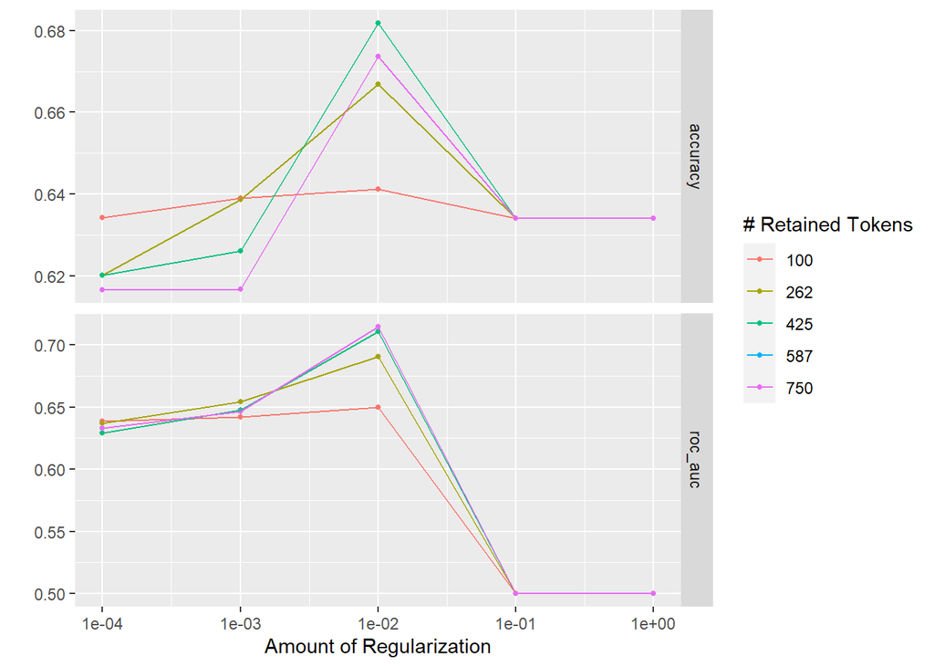

```r
tokenss<-autoplot(tweet_fit_rs_tune)
tokenss
```

```r
#ggsave("token.png",tokenss)
```

```r
# show best options
tweet_fit_rs_tune %>%
  show_best("roc_auc")
```

```
## # A tibble: 5 x 8
##   penalty max_tokens .metric .estimator  mean     n std_err .config
##     <dbl>      <int> <chr>   <chr>      <dbl> <int>   <dbl> <fct>
## 1   0.01         587 roc_auc binary     0.714    10  0.0129 Preprocessor4_Model3
## 2   0.01         750 roc_auc binary     0.714    10  0.0129 Preprocessor5_Model3
## 3   0.01         425 roc_auc binary     0.711    10  0.0135 Preprocessor3_Model3
## 4   0.01         262 roc_auc binary     0.691    10  0.0110 Preprocessor2_Model3
## 5   0.001        262 roc_auc binary     0.654    10  0.0157 Preprocessor2_Model2
```

```r
best_roc_auc <- select_best(tweet_fit_rs_tune, "roc_auc")

best_roc_auc
```

```
## # A tibble: 1 x 3
##   penalty max_tokens .config
##     <dbl>      <int> <fct>
## 1    0.01        587 Preprocessor4_Model3
```

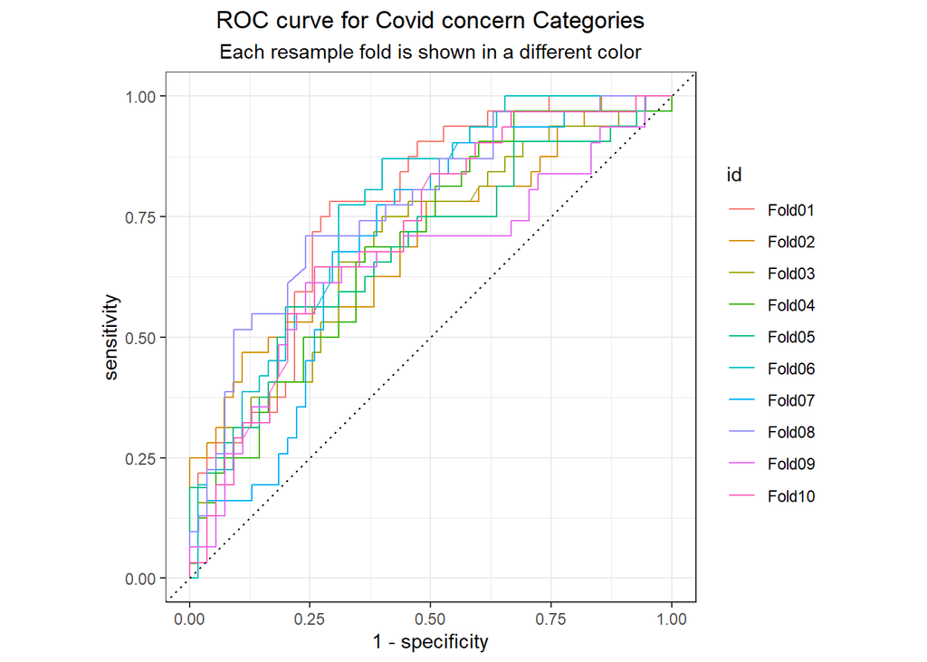

```r
collect_predictions(tweet_fit_rs_tune, parameters = best_roc_auc) %>%
  group_by(id) %>%
  roc_curve(truth = Is_CONCERNED, .pred_concerned) %>%
  autoplot() +
    theme(plot.title = element_text(hjust = 0.5),
        plot.subtitle = element_text(hjust = 0.5)) +
  labs(
    title = "ROC curve for Covid concern Categories",
    subtitle = "Each resample fold is shown in a different color"
  )
```

```r
tweet_wflow_final <- finalize_workflow(tweet_wflow_tune, best_roc_auc)
#ggsave("Tuned Roc by folds.png")
```

```r
# variable importance ----------------------------------------------------------

library(vip)

# vi_data <- tweet_wflow_final %>%
#  fit(tweet_train) %>%
#  pull_workflow_fit() %>%
#  vi(lambda = best_roc_auc$penalty) %>%
#  mutate(Variable = str_remove_all(Variable, "tfidf_text_")) %>%
#  filter(Importance != 0)

# write_rds(vi_data, here::here("data", "vi_data.rds"), compress = "xz")
```

[figure not shown]

```r
vi_data <- read_rds(here::here("data", "vi_data.rds"))

vi_data %>%
  mutate(
    Importance = abs(Importance)
  ) %>%
  filter(Importance != 0) %>%
  group_by(Sign) %>%
  slice_head(n = 20) %>%
  ungroup() %>%
  mutate(pred_Is_CONCERNED = if_else(Sign == "POS", "concerned", "not concerned")) %>%
  ggplot(aes(
    x = fct_reorder(Variable, Importance),
    y = Importance,
    fill = pred_Is_CONCERNED
  )) +
  geom_bar(stat = "identity") +
  theme_classic2() +
  theme(plot.title = element_text(hjust = 0.5)) +
  scale_fill_manual(values = c("black", "pink")) +
  facet_wrap(~pred_Is_CONCERNED, scales = "free") +
  labs(
    y = NULL
  ) +
  theme(legend.position = "none") +
  coord_flip() +
  labs(
    x = "Word",
    y = "Importance",
    title = "The most effective words in the classification."
  )
```

```r
#ggsave("Most effective words for Classifier.png")
```

A look at the most effective words for classification shows us that they are not the ones that trump tweets about the most - its the other way around. The more specific they are to a particular set of tweets, the more they help with classiiction.

```r
tweet_fit_final <- last_fit(
  tweet_wflow_final,
  tweet_split
)

write_rds(tweet_fit_final, here::here("data", "tweet_fit_final.rds"), compress = "xz")
```

Accuracy and roc_auc of the model

```r
tweet_fit_final <- read_rds(here::here("data", "tweet_fit_final.rds"))

tweet_fit_final %>%
  collect_metrics()
```

```
## # A tibble: 2 x 4
##   .metric  .estimator .estimate .config
##   <chr>    <chr>          <dbl> <chr>
## 1 accuracy binary         0.662 Preprocessor1_Model1
## 2 roc_auc  binary         0.715 Preprocessor1_Model1
```

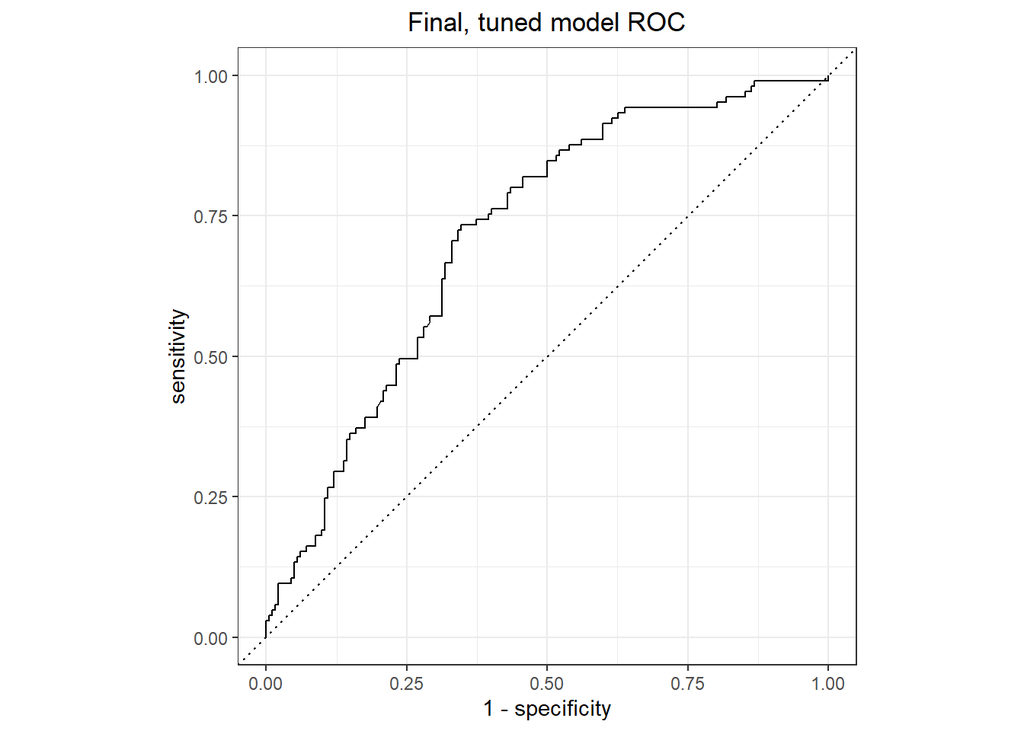

```r
# Graoh final predictions
tweet_fit_final %>%
  collect_predictions() %>%
  roc_curve(truth = Is_CONCERNED, .pred_concerned) %>%
  autoplot() +
  theme(plot.title = element_text(hjust = 0.5)) +
  labs(title = "Final, tuned model ROC")
```

```r
#ggsave("Tuned model roc.png")
```

Our tuned Roc seems to have done slightly better than the original model, however the improvement by tuning seems to only have been incremental.

Finally, lets take a look at our predictions:

```r
# predict
tweet_test_pred_new <- tweet_fit_final %>%
  collect_predictions() %>%
  bind_cols(tweet_test %>% select(Is_CONCERNED, text, isRetweet, wday,n_words,
                                  pos_ratio, neg_ratio))
tweet_test_pred_new %>% head(10)
```

```
## # A tibble: 10 x 14
##    id       .pred_concerned `.pred_not conce~  .row .pred_class Is_CONCERNED...6
##    <chr>              <dbl>             <dbl> <int> <fct>       <fct>
##  1 train/t~          0.0446             0.955     3 not concer~ not concerned
##  2 train/t~          0.293              0.707     5 not concer~ not concerned
##  3 train/t~          0.524              0.476     6 concerned   not concerned
##  4 train/t~          0.118              0.882     8 not concer~ not concerned
##  5 train/t~          0.418              0.582    12 not concer~ not concerned
##  6 train/t~          0.786              0.214    16 concerned   not concerned
##  7 train/t~          0.162              0.838    19 not concer~ not concerned
##  8 train/t~          0.243              0.757    26 not concer~ not concerned
##  9 train/t~          0.465              0.535    30 not concer~ not concerned
## 10 train/t~          0.432              0.568    38 not concer~ not concerned
## # ... with 8 more variables: .config <chr>, Is_CONCERNED...8 <fct>, text <chr>,
## #   isRetweet <lgl>, wday <dbl>, n_words <int>, pos_ratio <dbl>,
## #   neg_ratio <dbl>
```